# Copenhagen Part 2: Visualizations while performing clustering

### Get data ready for clustering

The `kohonen::supersom()` function accepts multilayered data sets, a named list in which each element consists of a matrix with an equal number of observations(rows). The function lets us specify which layer to include and lets us chose difference distance measures for each layer.

But first, we need to deal with the factors. Super Organized Maps (and neural networks in general) can not deal in category (factor) data types. You have to be creative on how you input them. In this case we are going to use `kohonen::classvec2classmat()` function which turns a factor column vector into a class matrix and vice versa. Differently from functions that convert a factor column vector into dummy variables, this function adds a single binary column per factor level i.e. [one hot encoding](https://www.quora.com/What-is-one-hot-encoding-and-when-is-it-used-in-data-science).

```r
## let's start by giving our dataset a fresh name.
data_val <- titanic

## identify which columns are numeric and which are factors
numerics = summarise_all(data_val, is.numeric ) %>%
  as.logical()

factors = names(data_val) %>%
  .[!numerics]

numerics = names(data_val) %>%
  .[numerics]

## Set up for loop
data_list = list()
distances = vector()

## This takes each factor column and makes into a matrix. Then you will have a list of matrices.

for (fac in factors){
  data_list[[fac]] = kohonen::classvec2classmat( data_val[[fac]] )
  distances = c(distances, 'tanimoto')
}

## This scales all the numeric data and
data_list[['numerics']] = scale(data_val[,numerics])
distances = c(distances, 'euclidean')

## Check out the data
str(data_list)
```

```
## List of 5
##  $ pclass  : num [1:1310, 1:3] 1 1 1 1 1 1 1 1 1 1 ...
##   ..- attr(*, "dimnames")=List of 2
##   .. ..$ : NULL
##   .. ..$ : chr [1:3] "1" "2" "3"
##  $ survived: num [1:1310, 1:2] 0 0 1 1 1 0 0 1 0 1 ...
##   ..- attr(*, "dimnames")=List of 2
##   .. ..$ : NULL
##   .. ..$ : chr [1:2] "0" "1"
##  $ sex     : num [1:1310, 1:3] 0 0 0 0 0 0 0 0 0 0 ...
##   ..- attr(*, "dimnames")=List of 2
##   .. ..$ : NULL
##   .. ..$ : chr [1:3] "" "female" "male"
##  $ embarked: num [1:1310, 1:4] 0 0 0 0 0 0 0 0 0 0 ...
##   ..- attr(*, "dimnames")=List of 2
##   .. ..$ : NULL
##   .. ..$ : chr [1:4] "" "C" "Q" "S"
##  $ numerics: num [1:1310, 1:2] 3.44 2.28 2.28 2.28 2.28 ...
##   ..- attr(*, "dimnames")=List of 2
##   .. ..$ : NULL
##   .. ..$ : chr [1:2] "fare" "FamilySize"
##   ..- attr(*, "scaled:center")= Named num [1:2] 33.3 1.88
##   .. ..- attr(*, "names")= chr [1:2] "fare" "FamilySize"
##   ..- attr(*, "scaled:scale")= Named num [1:2] 51.76 1.58
##   .. ..- attr(*, "names")= chr [1:2] "fare" "FamilySize"
```

```r
head(data_list$pclass)
```

```
##      1 2 3
## [1,] 1 0 0
## [2,] 1 0 0
## [3,] 1 0 0
## [4,] 1 0 0
## [5,] 1 0 0
## [6,] 1 0 0
```

```r
names(data_list)
```

```
## [1] "pclass"   "survived" "sex"      "embarked" "numerics"
```

```r
str(data_list$numerics)
```

```
##  num [1:1310, 1:2] 3.44 2.28 2.28 2.28 2.28 ...
##  - attr(*, "dimnames")=List of 2
##   ..$ : NULL
##   ..$ : chr [1:2] "fare" "FamilySize"
##  - attr(*, "scaled:center")= Named num [1:2] 33.3 1.88
##   ..- attr(*, "names")= chr [1:2] "fare" "FamilySize"
##  - attr(*, "scaled:scale")= Named num [1:2] 51.76 1.58
##   ..- attr(*, "names")= chr [1:2] "fare" "FamilySize"
```

## Performing the clustering

Now we finally get to performing the SOM.

**How do you know how many dimensions my grid will be?**

- There are ways to do this appropriately, but it is a little complex of a topic. One rule of thumb is just make sure you don’t get too many empty nodes. If you are doing a proper analysis, look into some of the tests you can perform [here](http://www.sthda.com/english/articles/29-cluster-validation-essentials/96-determining-the-optimal-number-of-clusters-3-must-know-methods/). It also fun to just change the number of dimensions and explore how the clusters change. When you do this you get a better idea how well the neural network performs.

**How do you know how many iterations you need?**

- This all depends on the training plot which we will look at after making the plot.

```r
## Setting the map dimension and iterations.
map_dimension = 8
n_iterations = 1000

## Set up SOM grid
## This is the actual grid that the clustering will occur
som_grid = kohonen::somgrid(xdim = map_dimension,
                            ydim = map_dimension,
                            topo = "hexagonal")

## I always set my seed to 8, becasue it is my favorite number
set.seed(8)
m = kohonen::supersom(data_list,
                   grid = som_grid,
                   rlen = n_iterations,
                   alpha = 0.05,
                   whatmap = c(factors, 'numerics'),
                   dist.fcts = distances,
                   maxNA.fraction = .5)
```

## Visualizing using the Kohonen plotting functions

The Kohonen plotting functions are *really* amazing. They are simple to use and are extremely informative.

### Training Plot `changes`

As the SOM training iterations progress, the distance from each node’s weights to the samples represented by that node is reduced. Ideally, this distance should reach a minimum plateau. This plot option shows the progress over time. If the curve is continually decreasing, more iterations are required.

- Let’s go back and change the iterations to something low.

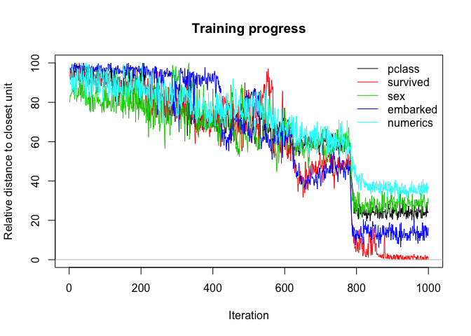

```r
plot(m, type = "changes")
```

Let’s look into some of the other default plotting functions.

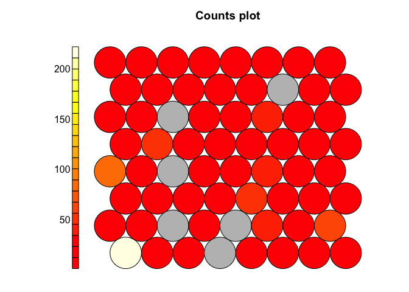

```r
plot(m, type = "counts")
```

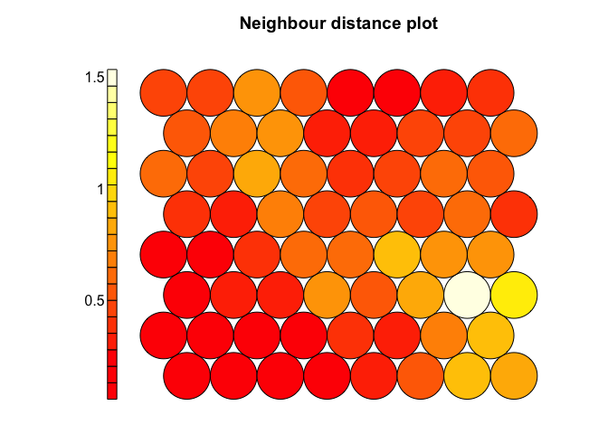

```r
plot(m, type = "dist.neighbours")
```

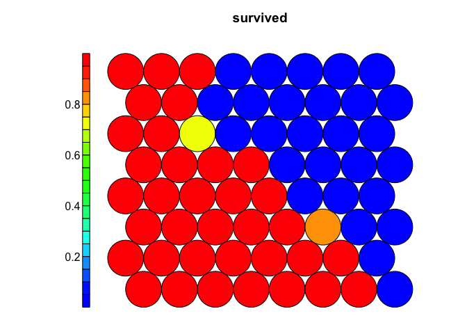

```r
## A little clunky on how to get the property plots to work with nested lists
## But the property plots are useful.

coolBlueHotRed <- function(n, alpha = 1) {rainbow(n, end=4/6, alpha=alpha)[n:1]}


plot(m, type = "property", property = as.matrix(m$codes$survived[,1]), main = names(m$codes)[2], palette.name=coolBlueHotRed)
```

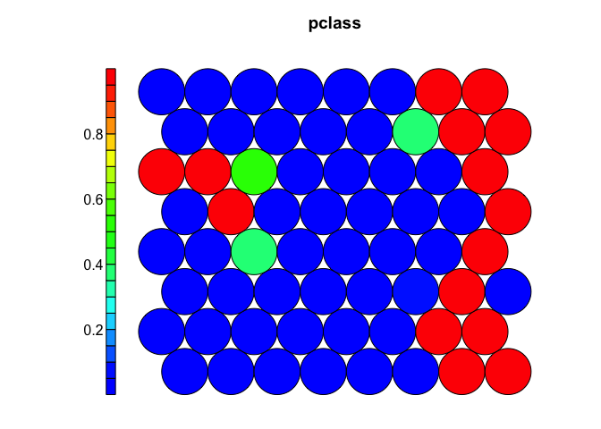

```r
plot(m, type = "property", property = as.matrix(m$codes$pclass[,1]), main = names(m$codes)[1], palette.name=coolBlueHotRed)
```

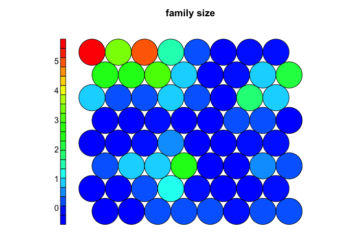

```r
plot(m, type = "property", property = as.matrix(m$codes$numerics[,2]), main = "family size", palette.name=coolBlueHotRed)
```

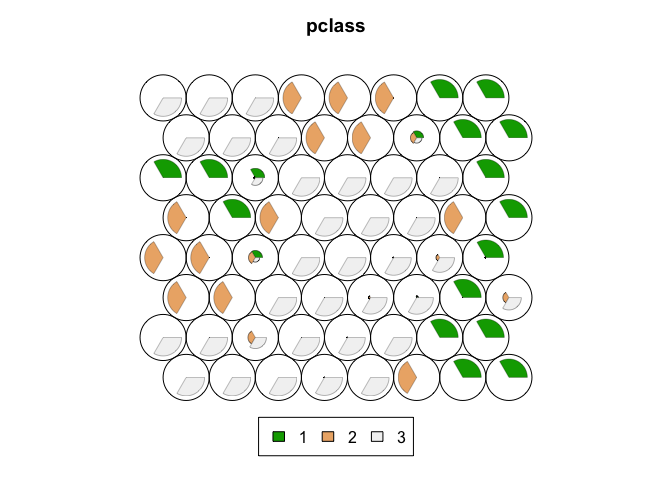

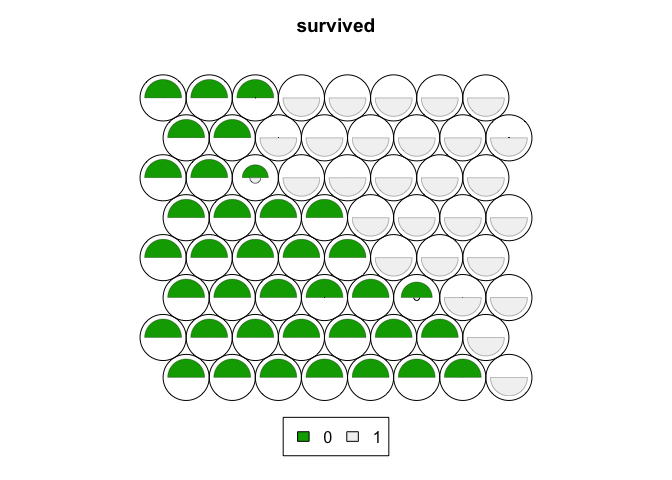

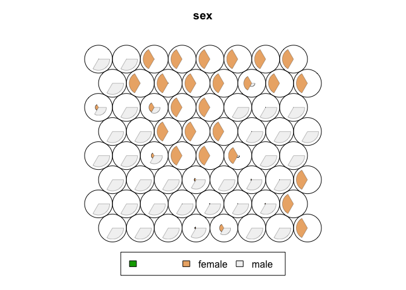

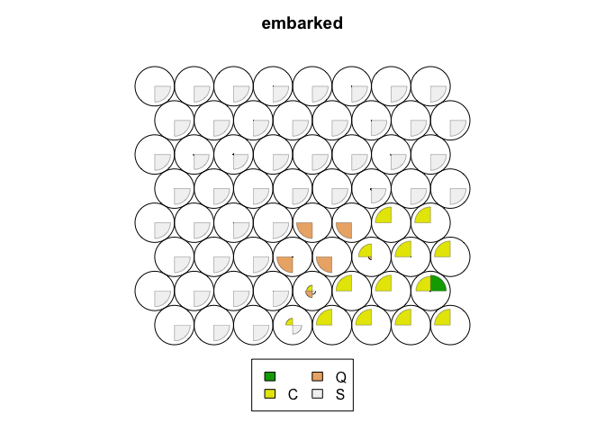

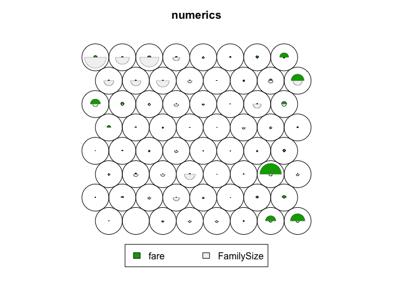

```r
plot(m, type = "codes")
```

## Understanding the output

Let check out the output of `supersom()`.

```r
names(m)
```

```
##  [1] "data"             "unit.classif"     "distances"
##  [4] "grid"             "codes"            "changes"
##  [7] "alpha"            "radius"           "user.weights"
## [10] "distance.weights" "whatmap"          "maxNA.fraction"
## [13] "dist.fcts"
```

```r
class(m) #class kohonen
```

```
## [1] "kohonen"
```

What we have here is a list of 13. The parts of the data that are really important are

- `unit.classif` = this is the cluster assignments.
- `codes` = the abstracted weights that describe each category in each cluster and ultimately decided what which person was put into which clusters.

Clusters only really made sense to me once I brought the data back in. The coolest part is that I can all the data back to the original data by attaching `unit.classif` back to our original data.

```r
## the length is the same length as our titanic dataset
length(m$unit.classif)
```

```
## [1] 1310
```

```r
dim(titanic)
```

```
## [1] 1310    6
```

```r
titanic_SOM <- cbind(titanic, as.data.frame(m$unit.classif))

## Change column header so it makes more sense
colnames(titanic_SOM)[7] <- "cluster"
```

Now we can start to understand each cluster. For example, let’s look at a few clusters.

```r
## Let's look at one cluster
titanic_SOM %>%
  filter(m$unit.classif == 52)
```

```
##    pclass survived    sex  fare embarked FamilySize cluster
## 1       2        1 female 39.00        S          3      52
## 2       2        1 female 39.00        S          3      52
## 3       2        1 female 29.00        S          3      52
## 4       2        1 female 30.00        S          3      52
## 5       2        1 female 30.00        S          3      52
## 6       2        1 female 26.25        S          3      52
## 7       2        1 female 26.25        S          3      52
## 8       2        1 female 36.75        S          3      52
## 9       2        1 female 32.50        S          3      52
## 10      2        1 female 14.50        S          3      52
## 11      2        1 female 26.25        S          3      52
## 12      2        1 female 26.25        S          3      52
## 13      2        1 female 26.00        S          3      52
## 14      2        1 female 26.00        S          3      52
## 15      2        1 female 26.00        S          3      52
## 16      2        1 female 13.00        S          3      52
## 17      2        1 female 23.00        S          3      52
## 18      2        1 female 23.00        S          3      52
```

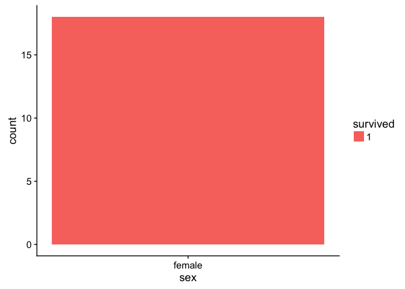

```r
titanic_SOM %>%
  filter(m$unit.classif == 52) %>%
  ggplot(., aes(sex, fill = survived)) +
    geom_bar()
```

Or lets look at the composite of all clusters

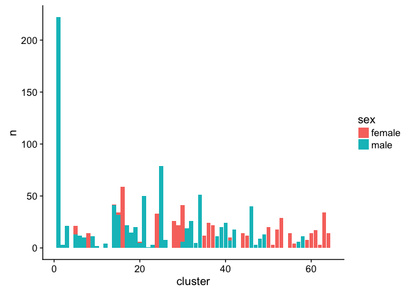

```r
cluster_tally  <- titanic_SOM %>%
  group_by(cluster, sex, survived) %>%
  tally() %>%
  na.omit()

ggplot(cluster_tally, aes(x = cluster, y = n, fill = sex))  +
  geom_bar(stat = "identity")
```

```r
## -  Why doesn't this work?
# titanic_SOM %>%
#   group_by(cluster, sex) %>%
#   tally() %>%
#   ggplot(cluster_tally, aes(x = cluster, y = n, fill = sex))  +
#   geom_bar(stat = "identity")
```

The graph above gives us an over view of how sex is distributed across clusters.

Or you can start to look into composite of all data within a single cluster.

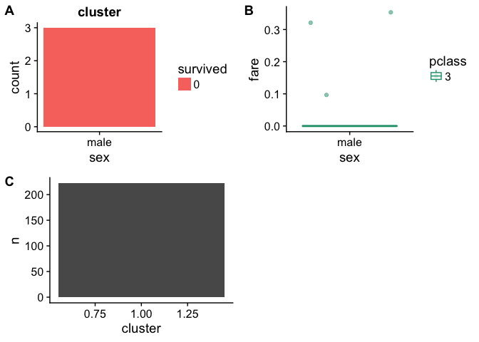

```r
cluster_descriptions <- function(clust_num) {
  #Graph 3
  survival_sex <- titanic_SOM %>%
    filter(cluster == clust_num) %>%
    ggplot(., aes(x = sex, fill = survived)) +
    geom_bar() +
    ggtitle(paste0(c("cluster", clust_num)))
  ## Graph 2
  fare_class <- titanic_SOM %>%
    filter(cluster == clust_num) %>%
    ggplot(., aes(x = sex, y = fare, color = pclass)) +
    geom_jitter(alpha = .5) +
    geom_boxplot(alpha = .7, outlier.size = 0) +
    scale_color_brewer(palette = "Dark2")
  ## Graph 3
  cluster_tally_1  <- titanic_SOM %>%
  filter(cluster == 1) %>%
  group_by(cluster, sex, survived) %>%
  tally() %>%
  na.omit()
  ## Graph 4
   tally <- ggplot(cluster_tally_1, aes(x = cluster,
                                     y = n))  +
     geom_bar(stat = "identity")
   ## put all together
  plot_grid(survival_sex, fare_class, tally, labels = c("A", "B", "C"), nrow = 2, align = "v")
}

cluster_descriptions(2)
```

A little messy, but you get the point. It is best to wrap these in functions and just explore the clusters. Go ahead and try a few different clusters.

You can try to add one more graph visualization to this function at home.

## Clustering Clusters: Hierarchical Clustering

Do get a even smaller set of clusters, you can further perform hierarchical clustering on the clusters. I have messed around with this feature in the past and the individuals in these “larger” clusters are the same individuals if you set the original supersom map size. So if you REALLY want to do this, you can just set the first map to prefer less clusters. Depends on what you are tying to ask. The main question I ask when I want less clusters is “What are the main data patterns that explain my data?”

```r
# fuse all layers into one dataframe
codes <- tibble(layers = names(m$codes),
               codes = m$codes ) %>%
  mutate( codes = purrr::map(codes, as_tibble)) %>%
  spread(key = layers, value = codes) %>%
  apply(1, bind_cols) %>%
  .[[1]] %>%
  as_tibble()

# generate distance matrix for codes
dist_m <- dist(codes) %>%
  as.matrix()

# generate seperate distance matrix for map location
dist_on_map <- kohonen::unit.distances(som_grid)

#exponentiate euclidean distance by distance on map
dist_adj = dist_m ^ dist_on_map
```

```r
dist_adj =  dist_m ^ dist_on_map
clust_adj = hclust(as.dist(dist_adj), 'ward.D2')
```

Set up the colors to define the clusters.

```r
library(RColorBrewer)
n <- 64
qual_col_pals = brewer.pal.info[brewer.pal.info$category == 'qual',]
col_vector = unlist(mapply(brewer.pal, qual_col_pals$maxcolors, rownames(qual_col_pals)))
```

Now that we have the colors we can use the `cutree` function to further separate the clusters into larger units.

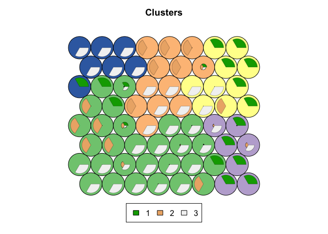

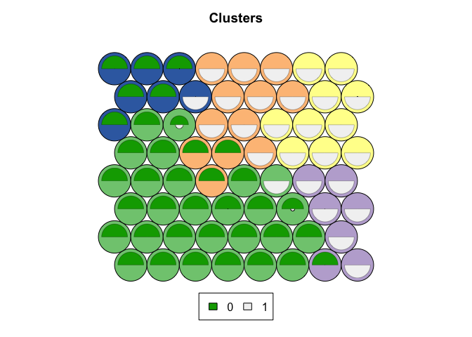

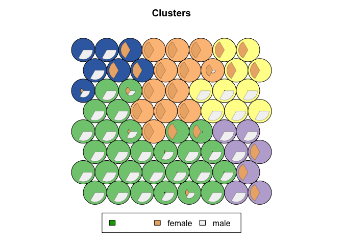

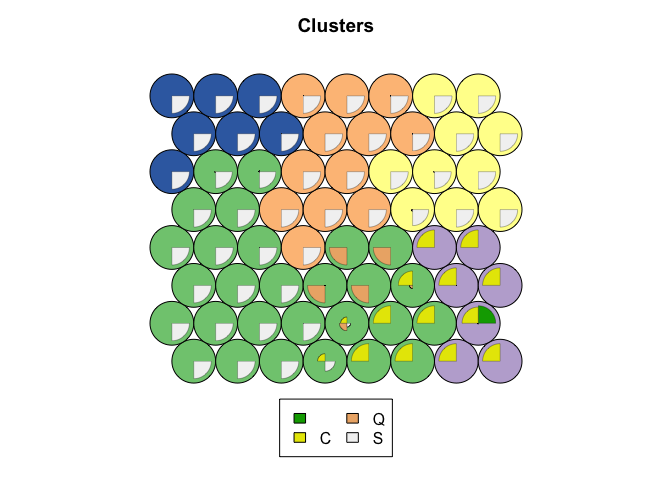

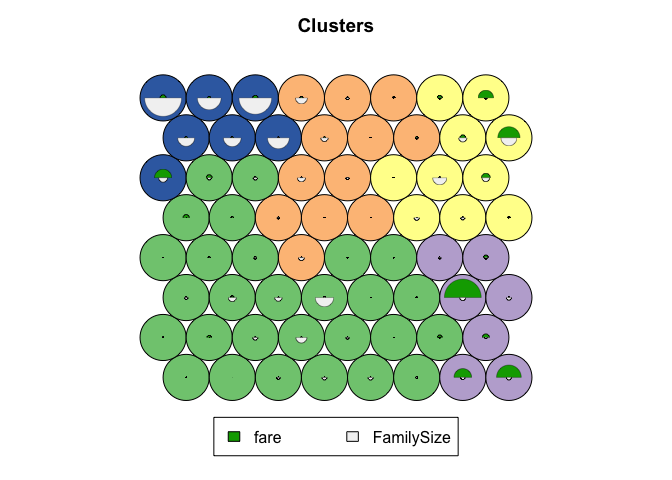

```r
som_cluster_adj = cutree(clust_adj, 5)

## -  Make sure you look through all the plots generated
plot(m, type="codes", main = "Clusters", bgcol = col_vector[som_cluster_adj], pchs = NA)
```

## Resources

[Developing SOM + Hierarchical Clustering + Connectivity Constrains](https://rpubs.com/erblast/SOM) - very nice overview of SOM analysis using the Kohonen package. [Determing optimal number of clusters](http://www.sthda.com/english/articles/29-cluster-validation-essentials/96-determining-the-optimal-number-of-clusters-3-must-know-methods/)